# Tugas Kelompok Anreg

Salsabila Fayiza_G1401221036 Delia Fitri Audina_G1401221013 Muhammad Abdan Rofi_G1401221059

2024-02-07

```r
library(readxl)
data <- read.csv("D:/IPB/SEMESTER 4/Analisis Regresi/Pertemuan 3/Tukel/data harga mobil.csv")
y<-data$price
x1<-data$horsepower

data<-data.frame(cbind(y,x1))
head(data)
```

```
##       y  x1
## 1 13495 111
## 2 16500 111
## 3 16500 154
## 4 13950 102
## 5 17450 115
## 6 15250 110
```

```r
n <- nrow(data)
n
```

```
## [1] 200
```

PEMBENTUKAN MODEL TANPA FUNGSI BAWAAN (MANUAL) #Parameter regresi

```r
b1<-(sum(x1*y)-sum(x1)*sum(y)/n)/(sum(x1^2)-(sum(x1)^2/n))
b0<-mean(y)-b1*mean(x1)

b1
```

```
## [1] 172.3164
```

```r
b0
```

```
## [1] -4573.358
```

INTERPRETASI B1 Nilai slope (b1) yang diperoleh sebesar 172.3164 ini menunjukkan bahwa terdapat hubungan positif antara harga mobil (y) dan kecepatan kuda (x).Ini menunjukkan bahwa untuk setiap peningkatan satu satuan kecepatan kuda (x), maka harga mobil (y) meningkat sebesar 172.3164.

UKURAN KERAGAMAN ##jumlah kuadrat

```r
galat <- y-(b0+b1*x1)
JKG <- sum((y - (b0+b1*x1))^2)
JKG
```

```
## [1] 4313966375
```

```r
JKReg <- sum(((b0+b1*x1)- mean(y))^2)
JKReg
```

```
## [1] 8295483837
```

```r
JKT <- sum((y - mean(y))^2)
JKT
```

```
## [1] 12609450213
```

##Derajat bebas

```r
dbReg <- 1
dbReg
```

```
## [1] 1
```

```r
dbg <- n-2
dbg
```

```
## [1] 198
```

```r
dbt <- n-1
dbt
```

```
## [1] 199
```

```r
Fhit <- (JKReg/dbReg)/(JKG/dbg)
Fhit
```

```
## [1] 380.7414
```

PERSAMAAN REGRESI LINEAR SEDERHANA

```r
model <- lm(y~x1, data)
summary(model)
```

```
##
## Call:
## lm(formula = y ~ x1, data = data)
##
## Residuals:
##      Min       1Q   Median       3Q      Max
## -10190.9  -2236.9   -471.3   1777.6  18267.1
##
## Coefficients:
##              Estimate Std. Error t value Pr(>|t|)
## (Intercept) -4573.358    970.285  -4.713 4.58e-06 ***
## x1            172.316      8.831  19.513  < 2e-16 ***
## ---
## Signif. codes:  0 '***' 0.001 '**' 0.01 '*' 0.05 '.' 0.1 ' ' 1
##
## Residual standard error: 4668 on 198 degrees of freedom
## Multiple R-squared:  0.6579, Adjusted R-squared:  0.6562
## F-statistic: 380.7 on 1 and 198 DF,  p-value: < 2.2e-16
```

INTERPRETASI PERSAMAAN REGRESI Berdasarkan perhitungan, diperoleh dugaan persamaan regresi linear Y_duga = -4573.358 + 172.3164x.Dapat disimpulkan bahwa semakin tinggi kecepaatan, maka semakin besar kemungkinian harga mobilnya semakin meningkat sebesar 172.3164.

Scatter Plot

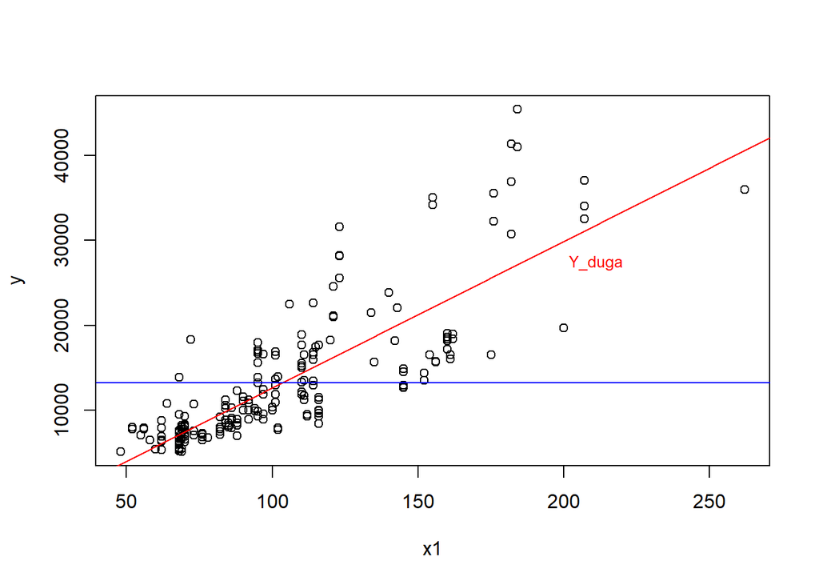

```r
y.bar <- mean(y)
plot(x1,y)
abline(model, col="red")
text(200, 29000, "Y_duga", adj =c(-0.1, 1.5), col = "red", cex = 0.8)
abline(h=y.bar, col = "blue")
text(30000, 95, "Y_bar", adj = c(0.1, 1.5), col = "blue", cex = 0.8)
```

```r
anova.model <- anova(model)
anova.model
```

```
## Analysis of Variance Table
##
## Response: y
##            Df     Sum Sq    Mean Sq F value    Pr(>F)
## x1          1 8295483837 8295483837  380.74 < 2.2e-16 ***
## Residuals 198 4313966375   21787709
## ---
## Signif. codes:  0 '***' 0.001 '**' 0.01 '*' 0.05 '.' 0.1 ' ' 1
```

```r
(KTG <- anova.model$'Mean Sq'[2])
```

```
## [1] 21787709
```

Setelah perhitungan anova, diperoleh nilai JKR = 8295483837, JKG = 4313966375, JKT = 12609450213, KTG = 21787709, dan KTR = 8295483837.

Galat Baku

```r
galat_baku <- sqrt(KTG)
galat_baku
```

```
## [1] 4667.731
```

KORELASI

```r
r<-(sum(x1*y)-sum(x1)*sum(y)/n)/
sqrt((sum(x1^2)-(sum(x1)^2/n))*(sum(y^2)-(sum(y)^2/n)))
r
```

```
## [1] 0.811097
```

INTERPRETASI Diperoleh korelasi sebesar 0.811097 yang berarti nilai kekuatan hubungan antara kecepatan kuda terhadap harga mobil menunjukkan korelasi yang positif kuat yang sangat baik untuk menjelaskan hubungan antara x dan y. Jadi, semakin meningkatnya kecepatan kuda maka harga mobil akan semakin meningkat.

Koefisien Determminasi

```r
Koef_det<-r^2
Koef_det
```

```
## [1] 0.6578783
```

INTERPRETASI Diperoleh koefisien determinasi sebesar 0.6578783 menunjukkan model regresi yang baik dalam menggambarkan hubungan antara variabel x dan y, mengingat tingkat koefisien determinasi yang paling baik adalah 1.

ADJUSTED R SQUARE

```r
Adj_R2<-1-((1-Koef_det)*(n-1)/(n-1-1))
Adj_R2
```

```
## [1] 0.6561504
```

INTERPRETASI Berdasarkan perhitungan diperoleh R2 = 0.6561504 yakni sekitar 65% yang menunjukkan besar ukuran kecepatan kuda (x) dapat menjelaskan variabel harga mobil (y), ini berarti sekitar 65% dari variasi dalam harga mobil dapat dijelaskan oleh kecepatan kuda pada model regresi.

UJI HIPOTESIS B0

```r
(KTG <- anova.model$'Mean Sq'[2])
```

```
## [1] 21787709
```

```r
(se_b0 <- sqrt(KTG*(1/n+mean(x1)^2/sum((x1-mean(x1))^2))))
```

```
## [1] 970.2852
```

```r
(t_b0 <- b0/se_b0)
```

```
## [1] -4.713417
```

UJI HIPOTESIS B1

```r
(se_b1 <- sqrt(KTG/sum((x1-mean(x1))^2)))
```

```
## [1] 8.831035
```

```r
(t_b1 <- b1/se_b1)
```

```
## [1] 19.5126
```

PENJELASAN UJI HIPOTESIS B1 H0: 𝛽1 = 0 (Tidak ada hubungan linier antara kecepatan kuda dan harga mobil) H1: 𝛽1 ≠ 0 (Ada hubungan linier antara kecepatan kuda dan harga mobil) t_tabel = 1,972017478 Karena nilai t1 = 19.5126 > t tabel = 1,972017478, maka tolak H0 artinya ada hubungan linear antara kecepatan kuda dan harga mobil. Terdapat cukup bukti untuk menyatakan bahwa kecepatan kuda memengaruhi harga mobil pada taraf nyata 5%.

PENDUGA SELANG KEPERCAYAAN 95% BAGI B1

```r
#batas bawah b1
(bb.b1 <- b1 - abs(qt(0.025, df=n-2))*se_b1)
```

```
## [1] 154.9015
```

```r
#batas atas b1
(ba.b1 <- b1 + abs(qt(0.025, df=n-2))*se_b1)
```

```
## [1] 189.7314
```

Pada tingkat kepercayaan 95% dapat dinyatakan parameter b1 berada dalam selang 154.9015 hingga 189.7314.

PENDUGA SELANG KEPERCAYAAN 95% BAGI B0

```r
#batas bawah b0

(bb.b0 <- b0 - abs(qt(0.025, df=n-2))*se_b0)
```

```
## [1] -6486.778
```

```r
#batas atas b0
(ba.b0 <- b0 + abs(qt(0.025, df=n-2))*se_b0)
```

```
## [1] -2659.939
```

Pada tingkat kepercayaan 95% dapat dinyatakan parameter b0 berada dalam selang -6486.778 hingga -2659.939.

SELANG KEPERCAYAAN RATAAN AMATAN

```r
amatan.diduga <- data.frame(x1=4,1)
predict(model, amatan.diduga, interval = "confidence")
```

```
##         fit       lwr       upr
## 1 -3884.093 -5732.158 -2036.027
```

SELANG KEPERCAYAAN INDIVIDU AMATAN

```r
predict(model, amatan.diduga, interval = "prediction")
```

```
##         fit       lwr     upr
## 1 -3884.093 -13272.63 5504.44
```